# The Market as of June 2019

VIX and an inverted yield curve

Martin Geissmann

6/4/2019

# What’s up?

- US’ new deal policy
  - trade war China, US, Mexico
  - import taxes and trade barriers (Huawei)
- instability in middle East
  - Iran, Isreal, Saudi Arabia
  - Turkey
- EU
  - post parliament elections
  - Austria Ibiza scandal
  - Brexit
- China more fragile than thought

# Equities

First let’s load some R packages. Note that for [Quandl](https://www.quandl.com/) you need a API code that is for free but required registration.

```r
library(tidyverse)
library(tidyquant)
# library(gganimate)
library(ggrepel)
library(readr)
library(Quandl)

Quandl.api_key(read_file("quandl.key"))
```

We are interested in actual investable ETFs, i.e.

- SPY for the S&P 500
- QQQ for Nasdaq
- EWL tracking MSCI Switzerland
- GLD Gold
- SLV Silver
- TUR MSCI Turkey
- EWW MSCI Mexico
- GXC S&P China
- EGPT Egypt

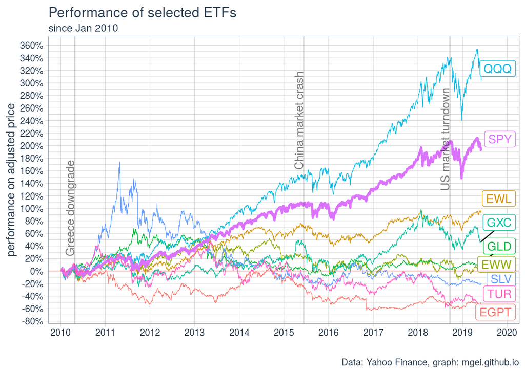

```r
# etfs <- tq_get(c("SPY", "QQQ", "EWL", "GLD", "SLV", "TUR", "EWW", "GXC", "EGPT"),
#                get  = "stock.prices",
#                from = "2009-01-01",
#                to   = Sys.Date())
#
# etfs %>% saveRDS("data/etfs.RDS")

etfs <- readRDS("data/etfs.RDS")

etfs %>%
  filter(date >= date("2010-01-01")) %>%
  group_by(symbol) %>%
  mutate(adjusted_rel = adjusted/first(adjusted)-1) %>%
  ungroup() %>%
  ggplot(aes(x = date, y = adjusted_rel, color = symbol, size = (symbol == "SPY"))) +
  geom_line() +
  geom_label_repel(aes(label = if_else(date == max(date), symbol, NA_character_)),
                   direction = "y", nudge_x = 1000, segment.color = "black", size = 4) +
  # Greece
  geom_vline(xintercept = date("2010-04-27"), alpha = 0.2) +
  annotate(geom = "text", x = date("2010-04-27")-40, y = 1, color = "black",
           label = "Greece downgrade", angle = 90, alpha = 0.5) +
  # China crash
  geom_vline(xintercept = date("2015-06-12"), alpha = 0.2) +
  annotate(geom = "text", x = date("2015-06-12")-40, y = 2.4, color = "black",
           label = "China market crash", angle = 90, alpha = 0.5) +
  # Mkr turndown
  geom_vline(xintercept = date("2018-09-20"), alpha = 0.2) +
  annotate(geom = "text", x = date("2018-09-20")-40, y = 2.1, color = "black",
           label = "US market turndown", angle = 90, alpha = 0.5) +
  geom_hline(yintercept = 0, color = "red", alpha = 0.2) +
  scale_y_continuous(labels = scales::percent, breaks = seq(-1, 6, by = 0.2)) +
  scale_x_date(limits = c(date("2010-01-01"), date("2019-12-31")), date_breaks = "1 year", date_labels = "%Y", expand = c(0, 100)) +
  scale_size_discrete(range = c(0.25, 1)) +
  labs(title = "Performance of selected ETFs", subtitle = "since Jan 2010",
       x = "", y = "performance on adjusted price",
       caption = "Data: Yahoo Finance, graph: mgei.github.io") +
  theme_tq() +
  theme(legend.position = "none")
```

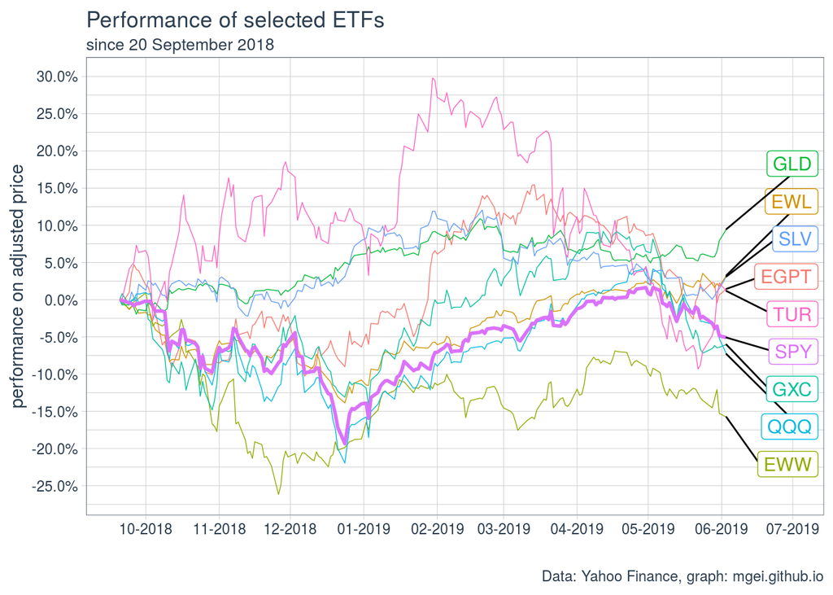

```r
etfs %>%
  filter(date >= date("2018-09-20")) %>%
  group_by(symbol) %>%
  mutate(adjusted_rel = adjusted/first(adjusted)-1) %>%
  ungroup() %>%
  ggplot(aes(x = date, y = adjusted_rel, color = symbol, size = (symbol == "SPY"))) +
  geom_line() +
  geom_label_repel(aes(label = if_else(date == max(date), symbol, NA_character_)),
                   direction = "y", nudge_x = 1000, segment.color = "black", size = 4) +
  scale_y_continuous(labels = scales::percent, breaks = seq(-1, 6, by = 0.05)) +
  scale_x_date(limits = c(date("2018-09-20"), date("2019-06-30")), date_breaks = "1 month", date_labels = "%m-%Y") +
  scale_size_discrete(range = c(0.25, 1)) +
  labs(title = "Performance of selected ETFs", subtitle = "since 20 September 2018 ",
       x = "", y = "performance on adjusted price",
       caption = "Data: Yahoo Finance, graph: mgei.github.io") +
  theme_tq() +
  theme(legend.position = "none")
```

# Indicators

## VIX

> The CBOE Volatility Index, known by its ticker symbol VIX, is a popular measure of the stock market’s expectation of volatility implied by S&P 500 index options. It is calculated and disseminated on a real-time basis by the Chicago Board Options Exchange (CBOE), and is commonly referred to as the fear index or the fear gauge. - https://en.wikipedia.org/wiki/VIX

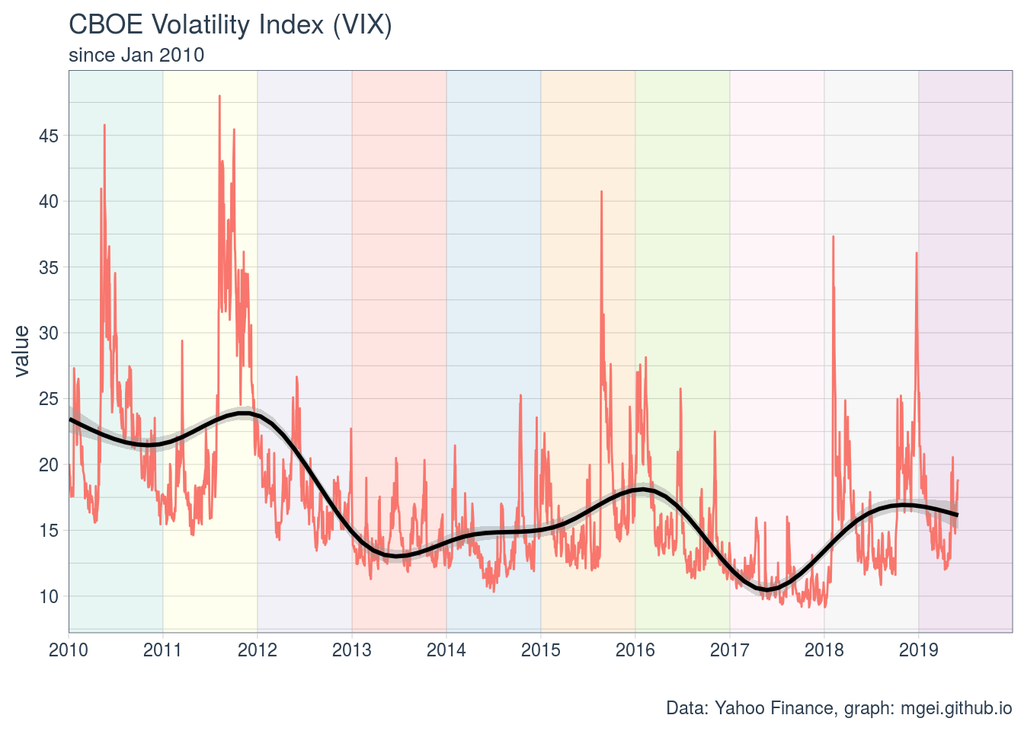

```r
# vix <- tq_get(c("^VIX"),
#                get  = "stock.prices",
#                from = "2009-01-01",
#                to   = Sys.Date()) %>%
#   mutate(symbol = "VIX")
#
# vix %>% saveRDS("data/vix.RDS")

vix <- readRDS("data/vix.RDS")

years <- tibble(year = seq(2010, 2019),
                from = seq.Date(date("2010-01-01"), date("2019-01-01"), by = "years"),
                to   = seq.Date(date("2010-12-31"), date("2019-12-31"), by = "years"))

vix %>%
  filter(year(date) >= 2010) %>%
  ggplot(aes(x = date, y = adjusted, color = symbol)) +
  geom_rect(data = years, inherit.aes = F, aes(xmin = from, xmax = to, ymin = -Inf, ymax = Inf, fill = factor(year)), alpha = 0.2) +
  geom_line() +
  geom_smooth(color = "black") +
  scale_x_date(date_breaks = "1 year", date_labels = "%Y", expand = c(0, 0)) +
  scale_y_continuous(breaks = seq(0,100, by = 5)) +
  scale_fill_brewer(type = "qual", palette = "Set3", guide = F) +
  labs(title = "CBOE Volatility Index (VIX)", subtitle = "since Jan 2010",
       x = "", y = "value", caption = "Data: Yahoo Finance, graph: mgei.github.io") +
  theme_tq() +
  theme(legend.position = "none")
```

## Yield curves

> In finance, the yield curve is a curve showing several yields or interest rates across different contract lengths (2 month, 2 year, 20 year, etc. …) for a similar debt contract. - https://en.wikipedia.org/wiki/Yield_curve

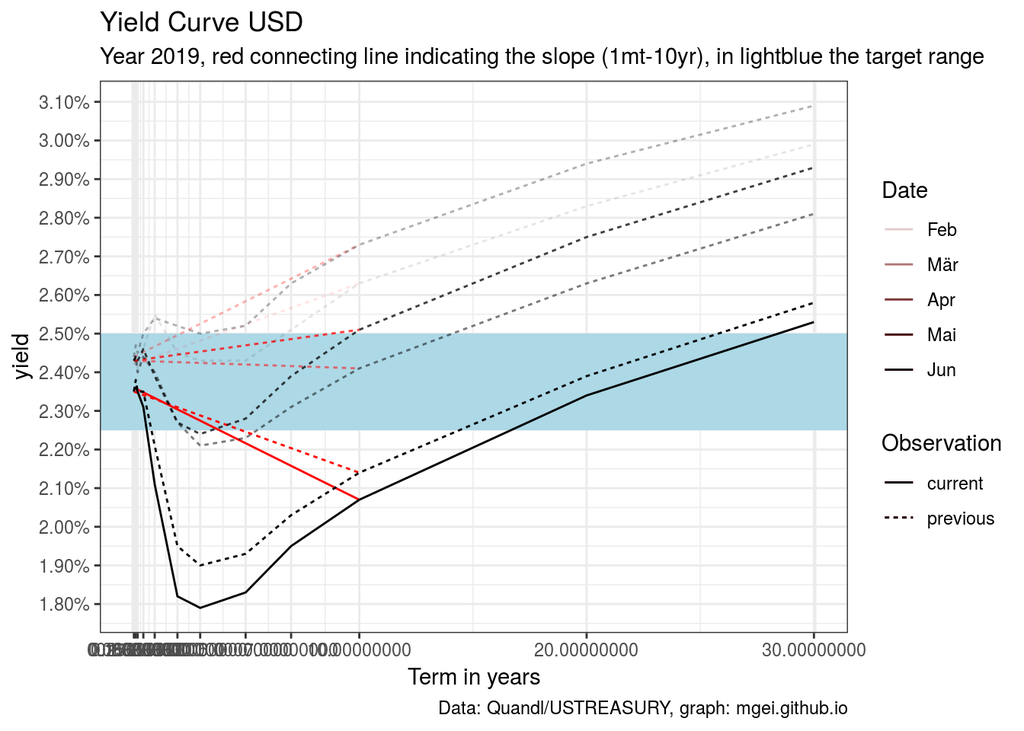

```r
# usd_yields_raw <- Quandl("USTREASURY/YIELD")
#
# usd_yields_raw %>% saveRDS("data/usd_yields_raw.RDS")

usd_yields_raw <- readRDS("data/usd_yields_raw.RDS")

usd_yields <- usd_yields_raw %>%
  as_tibble() %>%
  gather(term, Value, -Date) %>%
  mutate(term = case_when(term == "1 MO" ~ 1/12,
                          term == "2 MO" ~ 1/6,
                          term == "3 MO" ~ 1/4,
                          term == "6 MO" ~ 1/2,
                          T ~ str_remove(term, " YR") %>% as.numeric()))

usd_yields %>%
  filter(year(Date) %in% c(2019)) %>%
  group_by(month(Date)) %>%
  filter(Date == max(Date)) %>%
  ggplot(aes(x = term, y = Value/100, alpha = Date, group = Date, linetype = if_else(Date < max(Date), "previous", "current"))) +
  geom_rect(inherit.aes = F, aes(xmin = -Inf, xmax = Inf, ymin = 0.0225, ymax = 0.025),  fill = "lightblue") +
  geom_line(aes(x = if_else(term %in% c(1/12, 10), term, NA_real_), y = if_else(term  %in% c(1/12, 10), Value/100, NA_real_)), color = "red") +
  geom_line(color = "black") +
  labs(title = "Yield Curve USD", subtitle = "Year 2019, red connecting line indicating the slope (1mt-10yr), in lightblue the target range",
       x = "Term in years", y = "yield",
       caption = "Data: Quandl/USTREASURY, graph: mgei.github.io",
       linetype = "Observation") +
  scale_x_continuous(breaks = pull(unique(usd_yields["term"]))) +
  scale_y_continuous(breaks = seq(-0.01, 1, by = 0.001), labels = scales::percent) +
  theme_bw()
```

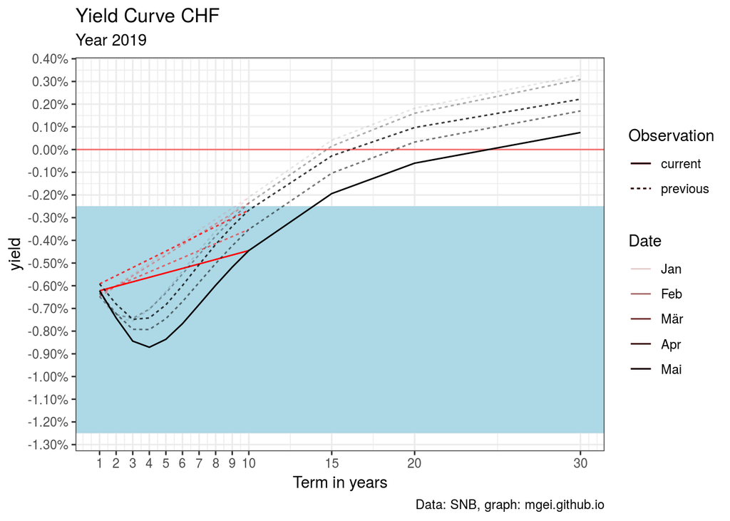

```r
chf_yiels <- read_csv2("snb-data-rendoblim-en-selection-20190603_1430.csv", skip = 3) %>%
  mutate(Date = ymd(paste0(Date, "-01")),
         term = D0 %>% str_remove("J") %>% as.numeric(),
         Value = as.numeric(Value))

chf_yiels %>%
  filter(year(Date) %in% c(2019)) %>%
  ggplot(aes(x = term, y = Value/100, alpha = Date, group = Date, linetype = if_else(Date < max(Date), "previous", "current"))) +
  geom_hline(yintercept = 0, color = "red", alpha = 0.5) +
  geom_hline(yintercept = -0.0075, color = "blue", alpha = 0.5) +
  geom_rect(inherit.aes = F, aes(xmin = -Inf, xmax = Inf, ymin = -0.0125, ymax = -0.0025),  fill = "lightblue") +
  geom_line(aes(x = if_else(term %in% c(1, 10), term, NA_real_), y = if_else(term  %in% c(1, 10), Value/100, NA_real_)), color = "red") +
  geom_line() +
  labs(title = "Yield Curve CHF", subtitle = "Year 2019",
       x = "Term in years", y = "yield",
       caption = "Data: SNB, graph: mgei.github.io",
       linetype = "Observation") +
  scale_x_continuous(breaks = pull(unique(chf_yiels["term"]))) +
  scale_y_continuous(breaks = seq(-0.015, 1, by = 0.001), labels = scales::percent) +
  theme_bw()
```

## Why care about the yield curve?

> The slope of the yield curve is one of the most powerful predictors of future economic growth, inflation, and recessions. - https://en.wikipedia.org/wiki/Yield_curve#Relationship_to_the_business_cycle

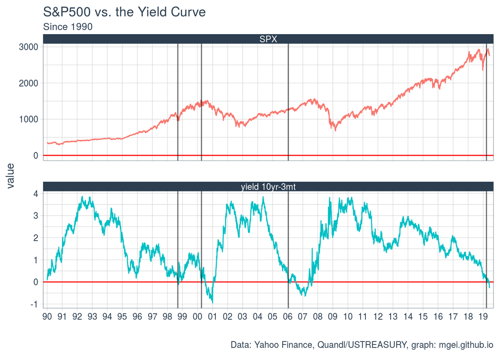

```r
# SPX <- tq_get("^GSPC", from = "1990-01-01")
#
# SPX %>% saveRDS("data/SPX.RDS")

SPX <- readRDS("data/SPX.RDS")

yield_curve <- usd_yields_raw %>%
  as_tibble() %>%
  mutate(adjusted = `10 YR` - `3 MO`,
         symbol = "yield 10yr-3mt") %>%
  select(date = Date, adjusted, symbol)

dropindicators <- yield_curve %>%
  filter(adjusted < 0) %>%
  group_by(year(date)) %>%
  filter(date == min(date)) %>%
  ungroup() %>%
  filter(week(date) > 1)

bind_rows(SPX %>% mutate(symbol = "SPX"),
          yield_curve) %>%
  ggplot(aes(x = date, y = adjusted, color = symbol)) +
  geom_hline(yintercept = 0, color = "red") +
  geom_line() +
  geom_vline(data = bind_rows(dropindicators, dropindicators %>% mutate(symbol = "SPX")), aes(xintercept = date), alpha = 0.6) +
  facet_wrap(~symbol, ncol = 1, scales = "free_y") +
  labs(title = "S&P500 vs. the Yield Curve", subtitle = "Since 1990",
       x = "", y = "value",
       caption = "Data: Yahoo Finance, Quandl/USTREASURY, graph: mgei.github.io",
       linetype = "Observation") +
  scale_x_date(date_breaks = "1 year", date_labels = "%y", expand = c(0, 100)) +
  scale_y_continuous() +
  # scale_size_continuous(breaks = c(0.25, 0.5)) +
  theme_tq() +
  theme(legend.position = "none")
```

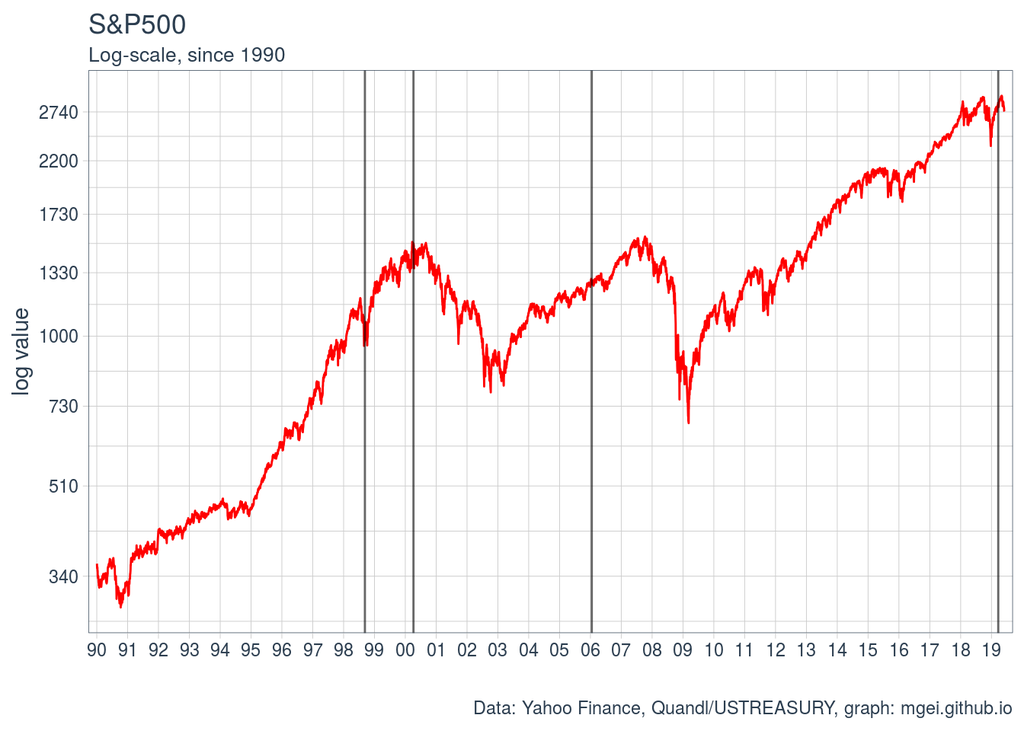

```r
SPX %>%
  ggplot(aes(x = date, y = adjusted)) +
  geom_line(color = "red") +
  geom_vline(data = bind_rows(dropindicators, dropindicators %>% mutate(symbol = "SPX")), aes(xintercept = date), alpha = 0.6) +
  labs(title = "S&P500", subtitle = "Log-scale, since 1990",
       x = "", y = "log value",
       caption = "Data: Yahoo Finance, Quandl/USTREASURY, graph: mgei.github.io",
       linetype = "Observation") +
  scale_x_date(date_breaks = "1 year", date_labels = "%y", expand = c(0, 100)) +
  scale_y_log10(breaks = round((1:100)^3, -1)) +
  # scale_size_continuous(breaks = c(0.25, 0.5)) +
  theme_tq() +
  theme(legend.position = "none")
```

To keep in mind is that interest rates were higher before the financial crisis.

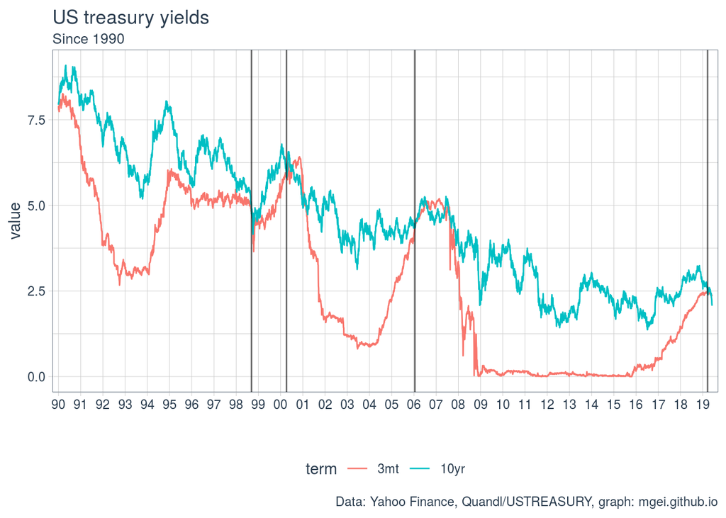

```r
usd_yields %>%
  filter(term %in% c(3/12, 10)) %>%
  ggplot(aes(x = Date, y = Value, color = factor(term), group = factor(term))) +
  geom_line() +
  geom_vline(data = bind_rows(dropindicators, dropindicators %>% mutate(symbol = "SPX")), aes(xintercept = date), alpha = 0.6) +
  labs(title = "US treasury yields", subtitle = "Since 1990",
       x = "", y = "value",
       color = "term",
       caption = "Data: Yahoo Finance, Quandl/USTREASURY, graph: mgei.github.io",
       linetype = "Observation") +
  scale_x_date(date_breaks = "1 year", date_labels = "%y", expand = c(0, 100)) +
  scale_color_discrete(labels = c("3mt", "10yr")) +
  # scale_y_log10() +
  # scale_size_continuous(breaks = c(0.25, 0.5)) +
  theme_tq()
```